# How Does a Bike-Share Navigate Speedy Success?

Samuel Sulo

April 16, 2023

### Introduction

As a junior data analyst working in the marketing analyst team at Cyclistic, a bike-share company in Chicago. The director of marketing believes the company’s future success depends on maximizing the number of annual memberships. Therefore, your team wants to understand how casual riders and annual members use Cyclistic bikes differently. From these insights, your team will design a new marketing strategy to convert casual riders into annual members. But first, Cyclistic executives must approve your recommendations, so they must be backed up with compelling data insights and professional data visualizations.

The assignment for the analytic team is to analyze available dataset to answer following questions:

1. How do annual members and casual riders use Cyclistic bikes differently?
2. Why would casual riders buy Cyclistic annual memberships?
3. How can Cyclistic use digital media to influence casual riders to become members?

But, Lily Moreno the director of marketing and my manager has assigned me the first question to answer on “How do annual members and casual riders use Cyclistic bikes differently?”.

Based on the key questions, I will make 3 hypothesis related:

1. Members and casual riders may have different ride durations.
2. Members and casual riders may have different ride lengths for days.
3. The season of the year has a significant effect on the number of bike rides taken, regardless of whether the riders are members or casual users.

For this analysis, the following libraries are used:

### Install and Load Packages

```r
library("tidyverse")
library("lubridate")
library("geosphere")
library("stats")
library("knitr")
```

### 1. Data Collection & Preparation.

For this project, I utilized the bike-sharing dataset for the year 2022, which can be downloaded from [here](https://divvy-tripdata.s3.amazonaws.com/index.html). The dataset is made available by Lyft Bikes and Scooters under the terms of this [license agreement](https://ride.divvybikes.com/data-license-agreement).

After storing the data locally, I verified the credibility of the data by checking if it is ROCC (reliable, original, comprehensive, current, and cited). Once I was confident in the data’s credibility, I opened the data to begin exploring and analyzing it.

Opening the data.

```r
# Upload Divvy datasets (csv files) here
Jan_2022 <- read.csv("C:/Users/User/Music/Bike_data_2022/202201_tripdata.csv")
Feb_2022 <- read_csv("C:/Users/User/Music/Bike_data_2022/202202_tripdata.csv")
Mar_2022 <- read_csv("C:/Users/User/Music/Bike_data_2022/202203_tripdata.csv")
Apr_2022 <- read_csv("C:/Users/User/Music/Bike_data_2022/202204_tripdata.csv")
May_2022 <- read_csv("C:/Users/User/Music/Bike_data_2022/202205_tripdata.csv")
Jun_2022 <- read_csv("C:/Users/User/Music/Bike_data_2022/202206_tripdata.csv")
Jul_2022 <- read_csv("C:/Users/User/Music/Bike_data_2022/202207_tripdata.csv")
Aug_2022 <- read_csv("C:/Users/User/Music/Bike_data_2022/202208_tripdata.csv")
Sept_2022 <- read_csv("C:/Users/User/Music/Bike_data_2022/202209_tripdata.csv")
Oct_2022 <- read_csv("C:/Users/User/Music/Bike_data_2022/202210_tripdata.csv")
Nov_2022 <- read_csv("C:/Users/User/Music/Bike_data_2022/202211_tripdata.csv")
Dec_2022 <- read_csv("C:/Users/User/Music/Bike_data_2022/202212_tripdata.csv")
```

### 2. Wrangle Data and Combine Into a Single File

In this section, is to prepare the data for analysis, but first i sorted and combined the datasets into a single file. While combining involved organizing and cleaning different datasets into a single file, and make sure the datasets column into same format.

```r
## 2.1 Create a list of monthly data frames for 2022.
monthly_data_2022 <- list(Jan_2022, Feb_2022, Mar_2022, Apr_2022,
                          May_2022, Jun_2022, Jul_2022, Aug_2022,
                          Sept_2022, Oct_2022, Nov_2022, Dec_2022)
```

```r
## Extract the column names of the first data frame.
colnames_2022 <- colnames(monthly_data_2022[[1]])

## Check if all data frames have the same column names as the first data frame.
consistent_colnames <- all(sapply(monthly_data_2022, function(df) all(colnames(df) %in% colnames_2022)))
```

#### 2.2 Check the data type

In this section is to check the “started_at” & “ended_at” column in each month’s data frame before stack all into 1 datasets

```r
# Use sapply to apply the function 'class' to each data frame in the list, and extract the class of the 'started_at' column for each month.
sapply(list(Jan_2022, Feb_2022, Mar_2022, Apr_2022, May_2022, Jun_2022,
            Jul_2022, Aug_2022, Sept_2022, Oct_2022, Nov_2022, Dec_2022),
       function(x) class(x$started_at))
```

```
## [[1]]
## [1] "character"
##
## [[2]]
## [1] "POSIXct" "POSIXt"
##
## [[3]]
## [1] "POSIXct" "POSIXt"
##
## [[4]]
## [1] "POSIXct" "POSIXt"
##
## [[5]]
## [1] "POSIXct" "POSIXt"
##
## [[6]]
## [1] "POSIXct" "POSIXt"
##
## [[7]]
## [1] "POSIXct" "POSIXt"
##
## [[8]]
## [1] "POSIXct" "POSIXt"
##
## [[9]]
## [1] "POSIXct" "POSIXt"
##
## [[10]]
## [1] "POSIXct" "POSIXt"
##
## [[11]]
## [1] "POSIXct" "POSIXt"
##
## [[12]]
## [1] "POSIXct" "POSIXt"
```

```r
sapply(list(Jan_2022, Feb_2022, Mar_2022, Apr_2022, May_2022, Jun_2022,
            Jul_2022, Aug_2022, Sept_2022, Oct_2022, Nov_2022, Dec_2022),
       function(x) class(x$ended_at))
```

```
## [[1]]
## [1] "character"
##
## [[2]]
## [1] "POSIXct" "POSIXt"
##
## [[3]]
## [1] "POSIXct" "POSIXt"
##
## [[4]]
## [1] "POSIXct" "POSIXt"
##
## [[5]]
## [1] "POSIXct" "POSIXt"
##
## [[6]]
## [1] "POSIXct" "POSIXt"
##
## [[7]]
## [1] "POSIXct" "POSIXt"
##
## [[8]]
## [1] "POSIXct" "POSIXt"
##
## [[9]]
## [1] "POSIXct" "POSIXt"
##
## [[10]]
## [1] "POSIXct" "POSIXt"
##
## [[11]]
## [1] "POSIXct" "POSIXt"
##
## [[12]]
## [1] "POSIXct" "POSIXt"
```

The’started_at’ and ‘ended_at’ columns in the first data frame (Jan_2022) are converted from character format to POSIXct format by the code, for further used analysis of date and time data.

```r
# Convert "started_at" & "ended_at" column to POSIXct in first data frame.
Jan_2022$started_at <- as.POSIXct(Jan_2022$started_at, format = "%Y-%m-%d %H:%M:%S")
Jan_2022$ended_at <- as.POSIXct(Jan_2022$ended_at, format = "%Y-%m-%d %H:%M:%S")
```

#### 2.3 Combine into single datasets

After convert the “started_at” & “ended_at” column to POSICT, now can combine into single datasets.

```r
# Stack all month data frames into one datasets.
bike_2022 <- bind_rows(Jan_2022, Feb_2022, Mar_2022,
                       Apr_2022, May_2022, Jun_2022,
                       Jul_2022, Aug_2022, Sept_2022,
                       Oct_2022, Nov_2022, Dec_2022)
```

```r
# Recheck structure after combined data frame.
str(bike_2022)
```

```
## 'data.frame':    5667717 obs. of  13 variables:
##  $ ride_id           : chr  "C2F7DD78E82EC875" "A6CF8980A652D272" "BD0F91DFF741C66D" "CBB80ED419105406" ...
##  $ rideable_type     : chr  "electric_bike" "electric_bike" "classic_bike" "classic_bike" ...
##  $ started_at        : POSIXct, format: "2022-01-13 03:59:47" "2022-01-10 00:41:56" ...
##  $ ended_at          : POSIXct, format: "2022-01-13 04:02:44" "2022-01-10 00:46:17" ...
##  $ start_station_name: chr  "Glenwood Ave & Touhy Ave" "Glenwood Ave & Touhy Ave" "Sheffield Ave & Fullerton Ave" "Clark St & Bryn Mawr Ave" ...
##  $ start_station_id  : chr  "525" "525" "TA1306000016" "KA1504000151" ...
##  $ end_station_name  : chr  "Clark St & Touhy Ave" "Clark St & Touhy Ave" "Greenview Ave & Fullerton Ave" "Paulina St & Montrose Ave" ...
##  $ end_station_id    : chr  "RP-007" "RP-007" "TA1307000001" "TA1309000021" ...
##  $ start_lat         : num  42 42 41.9 42 41.9 ...
##  $ start_lng         : num  -87.7 -87.7 -87.7 -87.7 -87.6 ...
##  $ end_lat           : num  42 42 41.9 42 41.9 ...
##  $ end_lng           : num  -87.7 -87.7 -87.7 -87.7 -87.6 ...
##  $ member_casual     : chr  "casual" "casual" "member" "casual" ...
```

### 3. Data Cleaning

An essential part of data preparation and analysis is handling missing values. Due to its simplicity and suitability for dataset, I will in this project remove any rows that have missing values .

```r
# Check and create new datasets for missing values in each column.
na_df <- bike_2022[rowSums(is.na(bike_2022)) > 0,]
nrow(na_df)
```

```
## [1] 1274801
```

```r
# Investigate how many missing values in the column within the datasets.
colSums(is.na(bike_2022))
```

```
##            ride_id      rideable_type         started_at           ended_at
##                  0                  0                  0                  0
## start_station_name   start_station_id   end_station_name     end_station_id
##             816804             816804             874815             874815
##          start_lat          start_lng            end_lat            end_lng
##                  0                  0               5858               5858
##      member_casual
##                  0
```

```r
# Calculate the percentage of rows with missing value indicating end_lat and end_lng.
(nrow(na_df[is.na(na_df$end_lat), ])/nrow(bike_2022))*100
```

```
## [1] 0.1033573
```

```r
(nrow(na_df[is.na(na_df$end_lng), ])/nrow(bike_2022))*100
```

```
## [1] 0.1033573
```

#### 3.1 Removing rows with missing data for my analysis

Cleaning the bike_2022 data frame by removing rows with missing values in the end_lat column. The end_lng the column also has missing values, but we only need to remove missing values in one of the columns, as they are highly correlated. By choosing the end_lat column to remove missing values, will automatically removes in the end_lng column.

```r
cleaned_data <- bike_2022[!is.na(bike_2022$end_lat),]
```

```r
# check the row remaining after deleting the missing values.
colSums(is.na(cleaned_data))
```

```
##            ride_id      rideable_type         started_at           ended_at
##                  0                  0                  0                  0
## start_station_name   start_station_id   end_station_name     end_station_id
##             816804             816804             869043             869043
##          start_lat          start_lng            end_lat            end_lng
##                  0                  0                  0                  0
##      member_casual
##                  0
```

```r
nrow(cleaned_data)
```

```
## [1] 5661859
```

#### 3.2 Removing column

After that, I will remove the following columns that not included for my analysis.

```r
# remove column start_station_name, start_station_id, end_station_name, end_station_id
cleaned_data <- cleaned_data %>%
  select(-c(start_station_name, start_station_id, end_station_name, end_station_id))
```

```r
# recheck the column
colnames(cleaned_data)
```

```
## [1] "ride_id"       "rideable_type" "started_at"    "ended_at"
## [5] "start_lat"     "start_lng"     "end_lat"       "end_lng"
## [9] "member_casual"
```

```r
# Recheck if there is still missing value
colSums(is.na(cleaned_data))
```

```
##       ride_id rideable_type    started_at      ended_at     start_lat
##             0             0             0             0             0
##     start_lng       end_lat       end_lng member_casual
##             0             0             0             0
```

Make sure there no more missing values from all columns then go to next step.

### 4. Preparing data for analysis

A crucial step in the data analysis process is preparing data for analysis, which entails converting raw data into a format that can be used for statistical analysis.This process involve creating new columns, and scaling or normalizing data to make it suitable for analysis.

#### 4.1 Inspect the new table that has been created

Understand the structure and characteristics the data frame. This include listing number of rows and dimensions of the data frame, previewing the first few rows of data, checking column data types, and getting a statistical summary of the data.

```r
#How many rows are in data frame.
nrow(cleaned_data)
```

```
## [1] 5661859
```

```r
#Dimensions of the data frame.
dim(cleaned_data)
```

```
## [1] 5661859       9
```

```r
#See the first 6 rows of data frame.
head(cleaned_data)
```

```
##            ride_id rideable_type          started_at            ended_at
## 1 C2F7DD78E82EC875 electric_bike 2022-01-13 03:59:47 2022-01-13 04:02:44
## 2 A6CF8980A652D272 electric_bike 2022-01-10 00:41:56 2022-01-10 00:46:17
## 3 BD0F91DFF741C66D  classic_bike 2022-01-24 20:53:40 2022-01-24 20:58:01
## 4 CBB80ED419105406  classic_bike 2022-01-03 16:18:04 2022-01-03 16:33:00
## 5 DDC963BFDDA51EEA  classic_bike 2022-01-19 17:31:10 2022-01-19 17:37:12
## 6 A39C6F6CC0586C0B  classic_bike 2022-01-11 10:48:09 2022-01-11 10:51:31
##   start_lat start_lng  end_lat   end_lng member_casual
## 1  42.01280 -87.66591 42.01256 -87.67437        casual
## 2  42.01276 -87.66597 42.01256 -87.67437        casual
## 3  41.92560 -87.65371 41.92533 -87.66580        member
## 4  41.98359 -87.66915 41.96151 -87.67139        casual
## 5  41.87785 -87.62408 41.88462 -87.62783        member
## 6  41.89563 -87.67207 41.90312 -87.67394        member
```

```r
#See list of columns and data types.
str(cleaned_data)
```

```
## 'data.frame':    5661859 obs. of  9 variables:
##  $ ride_id      : chr  "C2F7DD78E82EC875" "A6CF8980A652D272" "BD0F91DFF741C66D" "CBB80ED419105406" ...
##  $ rideable_type: chr  "electric_bike" "electric_bike" "classic_bike" "classic_bike" ...
##  $ started_at   : POSIXct, format: "2022-01-13 03:59:47" "2022-01-10 00:41:56" ...
##  $ ended_at     : POSIXct, format: "2022-01-13 04:02:44" "2022-01-10 00:46:17" ...
##  $ start_lat    : num  42 42 41.9 42 41.9 ...
##  $ start_lng    : num  -87.7 -87.7 -87.7 -87.7 -87.6 ...
##  $ end_lat      : num  42 42 41.9 42 41.9 ...
##  $ end_lng      : num  -87.7 -87.7 -87.7 -87.7 -87.6 ...
##  $ member_casual: chr  "casual" "casual" "member" "casual" ...
```

```r
#Statistical summary of data. Mainly for numerics.
summary(cleaned_data)
```

```
##    ride_id          rideable_type        started_at
##  Length:5661859     Length:5661859     Min.   :2021-12-31 16:00:05.0
##  Class :character   Class :character   1st Qu.:2022-05-28 19:17:08.5
##  Mode  :character   Mode  :character   Median :2022-07-22 15:11:15.0
##                                        Mean   :2022-07-20 07:18:40.2
##                                        3rd Qu.:2022-09-16 07:38:28.0
##                                        Max.   :2022-12-31 23:59:26.0
##     ended_at                        start_lat       start_lng
##  Min.   :2021-12-31 16:01:48.00   Min.   :41.64   Min.   :-87.84
##  1st Qu.:2022-05-28 19:37:21.00   1st Qu.:41.88   1st Qu.:-87.66
##  Median :2022-07-22 15:30:24.00   Median :41.90   Median :-87.64
##  Mean   :2022-07-20 07:34:59.95   Mean   :41.90   Mean   :-87.65
##  3rd Qu.:2022-09-16 07:51:35.00   3rd Qu.:41.93   3rd Qu.:-87.63
##  Max.   :2023-01-01 18:09:37.00   Max.   :45.64   Max.   :-73.80
##     end_lat         end_lng       member_casual
##  Min.   : 0.00   Min.   :-88.14   Length:5661859
##  1st Qu.:41.88   1st Qu.:-87.66   Class :character
##  Median :41.90   Median :-87.64   Mode  :character
##  Mean   :41.90   Mean   :-87.65
##  3rd Qu.:41.93   3rd Qu.:-87.63
##  Max.   :42.37   Max.   :  0.00
```

#### 4.2 Create new columns for analysis

Creating new columns for analysis is a crucial step in the data analysis process that involves deriving additional variables from existing data to gain insights and make more informed decisions. This process involves performing calculations or transformations on existing variables.

Creating new columns for the hour of the day, day of the week, months, or seasons can provide valuable insights into patterns and trends within the data. These new variables can be derived from existing datetime data, and can help identify peak usage times, seasonality effects, or other patterns that may impact analysis and decision-making.

```r
# Create new columns.
cleaned_data$hour_of_day <- hour(cleaned_data$started_at)
cleaned_data$day_of_week <- wday(cleaned_data$started_at, label = TRUE)
cleaned_data$month <- month(cleaned_data$started_at)
cleaned_data$season <- ifelse(month(cleaned_data$started_at) %in% c(3, 4, 5), "Spring",
                              ifelse(month(cleaned_data$started_at) %in% c(6, 7, 8), "Summer",
                                     ifelse(month(cleaned_data$started_at) %in% c(9, 10, 11),"Fall", "Winter")))
```

#### 4.3 Calculate and create new column for ride duration

Calculating the duration of each ride can provide valuable information on ride duration and usage patterns. This can be achieved by subtracting the ended_at and started_at for each ride in the dataset, resulting in a new column representing the duration of each ride as numeric.

```r
# Calculate ride duration in minutes.
cleaned_data$ride_duration_minutes <- as.numeric(difftime(cleaned_data$ended_at, cleaned_data$started_at, units = "mins"))
# Then format to 2 decimal points.
cleaned_data$ride_duration_minutes <- round(cleaned_data$ride_duration_minutes, 2)
```

After that, check if any negative ride duration values in the cleaned data and displays the corresponding start and end times. This is an important step in ensuring data accuracy and consistency, as negative ride duration values are likely indicate errors in data collection or processing.

```r
# check if negative numbers appear.
head(select(cleaned_data[cleaned_data$ride_duration_minutes < 0, ], c(started_at, ended_at, ride_duration_minutes)))
```

```
##                  started_at            ended_at ride_duration_minutes
## 403592  2022-03-05 11:00:57 2022-03-05 10:55:01                 -5.93
## 406769  2022-03-05 11:38:04 2022-03-05 11:37:57                 -0.12
## 1467056 2022-05-30 11:06:29 2022-05-30 11:06:17                 -0.20
## 1635638 2022-06-07 19:15:39 2022-06-07 17:05:37               -130.03
## 1636061 2022-06-07 19:14:46 2022-06-07 17:07:45               -127.02
## 1788334 2022-06-23 19:22:57 2022-06-23 19:21:46                 -1.18
```

```r
# Count the negative number appear in ride_duration_minutes.
nrow(cleaned_data[cleaned_data$ride_duration_minutes < 0, ])
```

```
## [1] 100
```

```r
# Calculate the percentage of negative values indicating on ride)_duration_minutes.
(nrow(cleaned_data[cleaned_data$ride_duration_minutes < 0, ])/nrow(cleaned_data))*100
```

```
## [1] 0.001766204
```

```r
# removes ride_duration_minutes column has a value less than 0, i.e. where there are negative ride duration.
cleaned_data <- cleaned_data[cleaned_data$ride_duration_minutes >= 0, ]
```

```r
# Print summary statistics of ride_durations_minutes.
summary(cleaned_data$ride_duration_minutes)
```

```
##     Min.  1st Qu.   Median     Mean  3rd Qu.     Max.
##     0.00     5.82    10.27    16.33    18.42 34354.07
```

#### 4.3 Calculate and create new column for ride length

Calculating the length of each ride can provide valuable information on ride length and usage patterns. This can be achieved by using the “start_lat” and “end_lat” and “geosphere package for each ride in the dataset, resulting in a new column representing the lentgh of each ride as numeric.

```r
# Create new column for ride_length in kilometers then add ride_length_km column and, divide by 1000 to convert meters to kilometers.
cleaned_data$ride_length_km <- geosphere::distHaversine(
  p1 = cbind(cleaned_data$start_lng, cleaned_data$start_lat),
  p2 = cbind(cleaned_data$end_lng, cleaned_data$end_lat)
) / 1000
```

```r
# Then format to 0 decimal points.
cleaned_data$ride_length_km <- round(cleaned_data$ride_length_km, 2)
```

### 5. Conduct Descriptive Analysis

For the descriptive analysis, this part involves exploring the data and summarizing its key characteristics, such as measures of central tendency, variability, and distribution. This type of analysis can provide insights into the patterns and trends present in the data, and help us understand the overall shape and structure of the data.

#### 5.1.1 General analysis comparing between member and casual

In this section, a general analysis is conducted to compare the usage patterns between members and casual. The aim is to gain insights into the differences in how the two types of riders use the bike-sharing service.

```r
# Create a table to comparing numbers between member and casual .
member_summary <- cleaned_data %>%
  group_by(member_casual) %>%
  summarise(count = n())
```

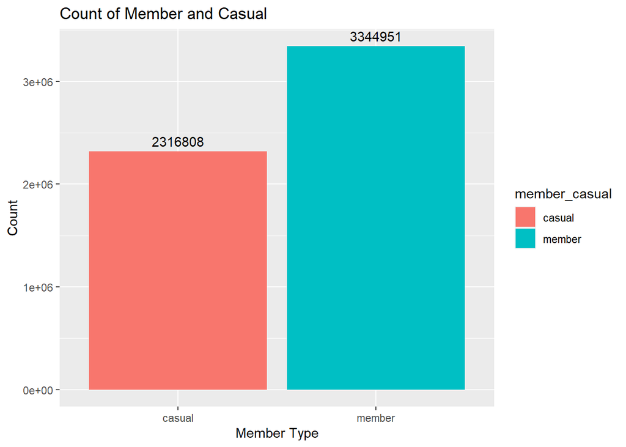

```r
# Graph for comparing number between member and casual.
ggplot(member_summary, aes(x = member_casual, y = count)) +
  geom_bar(aes(fill = member_casual), stat = "identity", position = "dodge") +
  geom_text(aes(label=count), stat="identity",
            position=position_dodge(width=0.9), vjust=-0.5) +
  labs(title = "Count of Member and Casual", x = "Member Type", y = "Count")
```

- As shown in the graph, its shows that count between member type ride bicycle and the total for member is 3344951 (59.08%) has a higher value than casual total 2316808 rides (40.92%).
- Concluded that members have utilized the bike-sharing service more frequently than casual riders.

#### 5.1.2 Comparing for average ride duration and ride length between member type

This section presents a general comparison between member and casual based on the average ride duration and ride length. By calculating the mean of these two variables, we can gain insights into the differences in riding patterns between the two groups. This information can be useful for understanding the ride behaviours and developing targeted marketing strategies.

```r
# Create table ride summary for ride_duration_minutes between member and casual.
ride_summary <- cleaned_data %>%
  group_by(member_casual) %>%
  summarize(avg_duration = mean(ride_duration_minutes),
            avg_length = mean(ride_length_km))
```

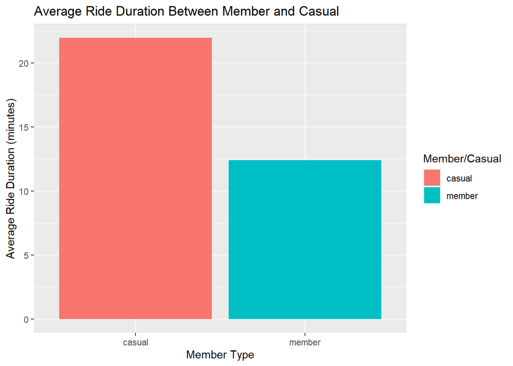

```r
# Graph for the ride duration(minutes) using ride summary between member and casual.
ggplot(ride_summary, aes(x = member_casual, y = avg_duration, fill = member_casual)) +
  geom_bar(stat = "identity", position = "dodge") +
  labs(x = "Member Type", y = "Average Ride Duration (minutes)", fill = "Member/Casual") +
  ggtitle("Average Ride Duration Between Member and Casual")
```

- From the chart above, the member type for casual has high number in average ride duration(minutes) with 21.99 minutes than member 12.41 minutes.
- Concluded that casual riders tend to have longer rides compared to member riders.

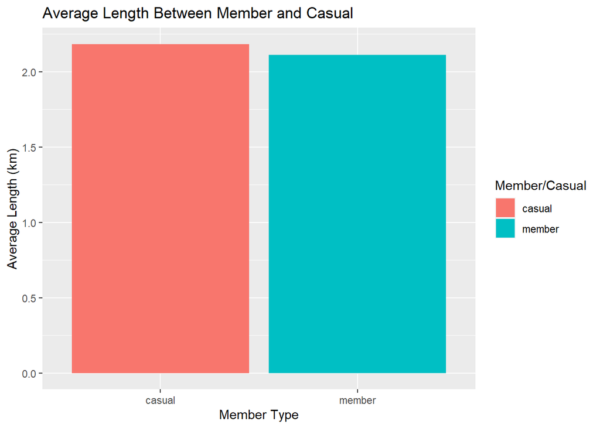

```r
# Graph for the ride length(km) using ride summary between member and casual.
ggplot(ride_summary, aes(x = member_casual, y = avg_length, fill = member_casual)) +
  geom_bar(stat = "identity", position = "dodge") +
  labs(x = "Member Type", y = "Average Length (km)", fill = "Member/Casual") +
  ggtitle("Average Length Between Member and Casual")
```

- As we can see graph above,we can see the a bit of difference on average length (km) between member type that casual has ride longer 2.183723 km than member 2.112977 km.
- Therefore, it can be concluded that, on average, casual riders tend to ride slightly farther compared to member riders.

#### 5.1.3 Popular rideable type between member and casual

This section aims to identify the most popular rideable type for both member and casual. By comparing the number of rides taken for each rideable type, we can gain insights into the preferences of each user group.

```r
# Create a dataframe to compare which rideable type has most ride by both member and casual.
rideable_counts <- cleaned_data %>%
  group_by(rideable_type, member_casual) %>%
  summarize(count = n())
knitr::kable(rideable_counts)
```

| rideable_type | member_casual | count |
| --- | --- | --- |
| classic_bike | casual | 888890 |
| classic_bike | member | 1709054 |
| docked_bike | casual | 174858 |
| electric_bike | casual | 1253060 |
| electric_bike | member | 1635897 |

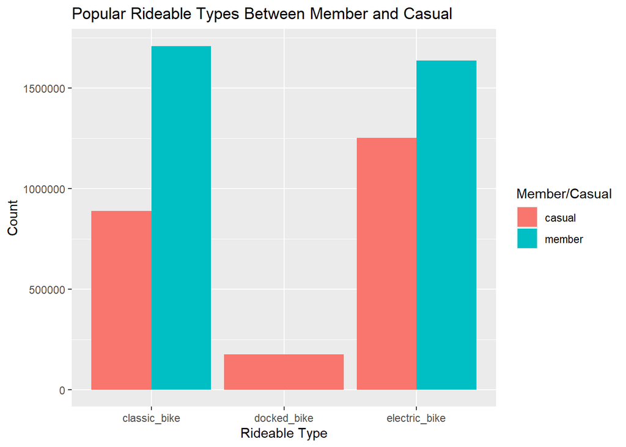

```r
# Graph which rideable type has most ride by both members and casual.
ggplot(rideable_counts, aes(x = rideable_type, y = count)) +
  geom_bar(aes(fill = member_casual), stat = "identity", position = "dodge") +
  labs(x = "Rideable Type", y = "Count", fill = "Member/Casual") +
  ggtitle("Popular Rideable Types Between Member and Casual")
```

#### 5.1.4 Rideable type most average duration between members and casual

This section aims to identify the rideable type with the highest average duration for both member and casual. By comparing the average duration of rides for each rideable type, we can gain insights into how each member type uses Cyclistic bikes differently.

```r
# Create dataframe and check which rideable type the most average duration between members and casual.
avg_duration_by_type <- cleaned_data %>%
  group_by(member_casual, rideable_type) %>%
  summarize(avg_duration = mean(ride_duration_minutes),
            avg_length = mean(ride_length_km))
knitr::kable(avg_duration_by_type)
```

| member_casual | rideable_type | avg_duration | avg_length |
| --- | --- | --- | --- |
| casual | classic_bike | 24.53221 | 2.087424 |
| casual | docked_bike | 50.70781 | 2.175997 |
| casual | electric_bike | 16.17394 | 2.253113 |
| member | classic_bike | 13.32055 | 1.965717 |
| member | electric_bike | 11.46272 | 2.266822 |

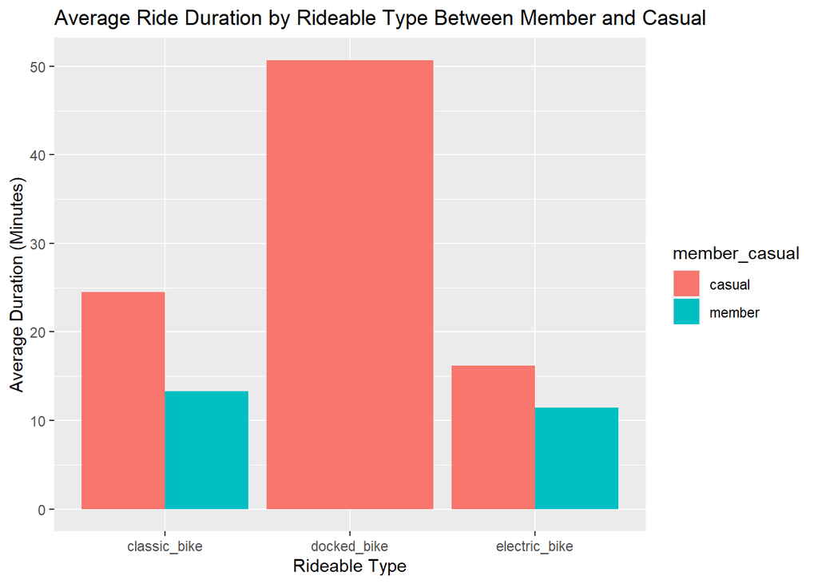

```r
# Graph to see the result for ride duration by rideable type between member and casual.
ggplot(avg_duration_by_type, aes(x = rideable_type, y = avg_duration,
                                 fill = member_casual)) +
  geom_bar(stat = "identity", position = "dodge") +
  labs(x = "Rideable Type", y = "Average Duration (Minutes)",
       title = "Average Ride Duration by Rideable Type Between Member and Casual")
```

- Based on graph above, we can see the 3 difference rideable type on average ride duration(minutes).
- From the classic bike, casual has average ride longer with 24.5 minutes than member 13.3 minutes. Same with electric bike also having the casual has average ride longer with 16.17 minutes than member 11.46 minutes.
- Notice that, docked bike has the most highest average duration with 50.7078 minutes than other 2 rideable type, which may indicate that this type preferred by casual who are looking for longer rides.

#### 5.2.1 Season analysis comparing between member and casual

Seasonal analysis of bike-sharing patterns reveals differences between member and casual. By conducting a seasonal analysis of bike-sharing patterns, we can gain insights into how members and casual differ in their bike usage habits throughout the year.

```r
# Create dataframe for both average ride duration and ride length by rideable type between members & casual for season.
rides_by_season <- cleaned_data %>%
  group_by(season, rideable_type, member_casual) %>%
  summarize(avg_ride_length = mean(ride_length_km),
            avg_ride_duration = mean(ride_duration_minutes))

knitr::kable(rides_by_season)
```

| season | rideable_type | member_casual | avg_ride_length | avg_ride_duration |
| --- | --- | --- | --- | --- |
| Fall | classic_bike | casual | 2.051708 | 22.40831 |
| Fall | classic_bike | member | 1.989286 | 12.77882 |
| Fall | docked_bike | casual | 2.179392 | 44.47659 |
| Fall | electric_bike | casual | 2.142633 | 14.04954 |
| Fall | electric_bike | member | 2.210474 | 10.99363 |
| Spring | classic_bike | casual | 2.109167 | 27.08755 |
| Spring | classic_bike | member | 1.909699 | 13.07919 |
| Spring | docked_bike | casual | 2.120987 | 53.03799 |
| Spring | electric_bike | casual | 2.367752 | 17.84304 |
| Spring | electric_bike | member | 2.194932 | 11.26554 |
| Summer | classic_bike | casual | 2.121717 | 24.52697 |
| Summer | classic_bike | member | 2.068572 | 14.25216 |
| Summer | docked_bike | casual | 2.214547 | 50.76781 |
| Summer | electric_bike | casual | 2.304302 | 17.23570 |
| Summer | electric_bike | member | 2.450307 | 12.37411 |
| Winter | classic_bike | casual | 1.618039 | 20.67457 |
| Winter | classic_bike | member | 1.613089 | 11.62504 |
| Winter | docked_bike | casual | 1.954290 | 79.95522 |
| Winter | electric_bike | casual | 1.927572 | 11.48674 |
| Winter | electric_bike | member | 1.954729 | 10.16456 |

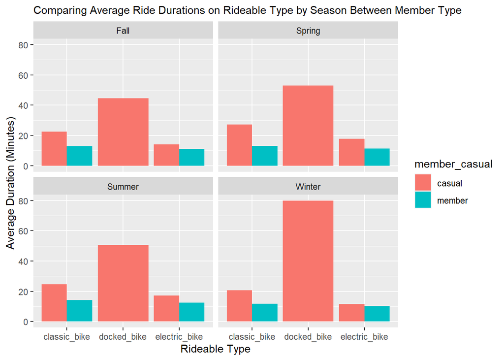

```r
# Plot the average ride duration by rideable type between member & casual for each season.
ggplot(rides_by_season, aes(x = rideable_type, y = avg_ride_duration, fill = member_casual)) +
  geom_bar(stat = "identity", position = "dodge") +
  labs(x = "Rideable Type", y = "Average Duration (Minutes)",
  title = "Comparing Average Ride Durations on Rideable Type by Season Between Member Type") +
  facet_wrap(~season) +
  theme(plot.title = element_text(size = 11))
```

- The analysis of bike-sharing patterns across different seasons reveals notable differences in the average ride length between casual and member users. During the Winter season, the average duration of classic bike rides was found to be 20.7 minutes for casual and 11.6 minutes for members. Similarly, for electric bikes, casual users had an average ride duration of 11.5 minutes, which was longer than the 10.17 minutes observed for member. In the Spring season, casual had the longest average ride duration of 27.1 minutes in classic bike, compared to 13.079 minutes for members.
- From the graph season in Fall, the average duration for classic bike has resulting the casual has more longer with 22.41 minutes than member 12.8 minutes. On the other hand,electric bike also resulting the casual ride more longer with 14.1 minutes than member with 10.99 minutes. The casual still has the most average ride duration in classic bike with 24.53 minutes than member with 14.25 minutes in Summer season and for electric bike also resulting the casual ride more longer with 17.24 minutes than member with 12.37 minutes.
- Interestingly, the analysis reveals that only casual who rented docked bike across all seasons. During Winter, the average ride duration for casual users was 79.96 minutes, while in Spring, Fall, and Summer seasons, the average ride duration were 53.04 minutes, 44.48 minutes, and 50.77 minutes, respectively.

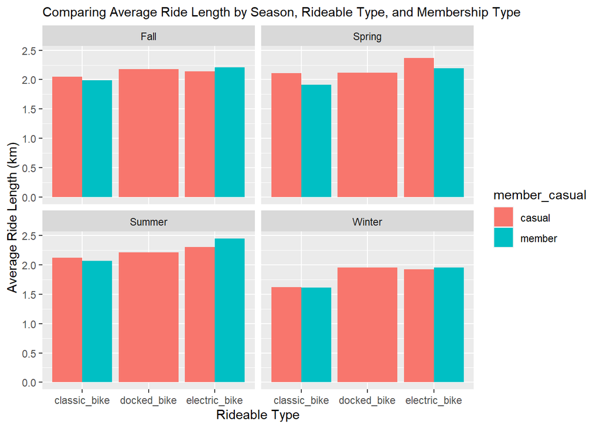

```r
# Plot the average ride length by rideable type between member & casual for season.
ggplot(rides_by_season, aes(x = rideable_type, y = avg_ride_length, fill = member_casual)) +
  geom_bar(stat = "identity", position = "dodge") +
  labs(x = "Rideable Type", y = "Average Ride Length (km)",
       title = "Comparing Average Ride Length by Season, Rideable Type, and Membership Type") +
  facet_wrap(~season) +
  theme(plot.title = element_text(size = 11))
```

The casual still has the most longer for average length in classic bike with 2.12 km than member with 2.07 in Summer season. But for electric bike resulting the average length for casual ride shorter with 2.30 km than member with 2.45 km

- Interestingly, the analysis reveals that only casual using rented docked bikes across all seasons. During Winter, the average ride length for casual users was 1.95 km, while in Spring, Fall, and Summer seasons, the average ride duration were 2.12 km, 2.18 km , and 2.22 km, respectively.

#### 5.2.1 Monthly analysis comparing between member and casual

The monthly analysis of bike-sharing patterns compares the usage between member and casual over different months. This analysis provides insights into how frequently users of each type use the bike-sharing service, how long their rides are, and how usage patterns differ between different months. These insights can help bike-sharing companies better understand their member type and optimize their services to meet their needs.

```r
# Create dataframe counting number which month has most ride between members & casual.
counts_by_month <- cleaned_data %>%
  group_by(month, member_casual) %>%
  summarize(count = n())
knitr::kable(counts_by_month)
```

| month | member_casual | count |
| --- | --- | --- |
| 1 | casual | 17879 |
| 1 | member | 84728 |
| 2 | casual | 21361 |
| 2 | member | 94171 |
| 3 | casual | 89642 |
| 3 | member | 194132 |
| 4 | casual | 126121 |
| 4 | member | 244811 |
| 5 | casual | 279764 |
| 5 | member | 354371 |
| 6 | casual | 368082 |
| 6 | member | 400055 |
| 7 | casual | 405179 |
| 7 | member | 417346 |
| 8 | casual | 358161 |
| 8 | member | 426913 |
| 9 | casual | 296074 |
| 9 | member | 404544 |
| 10 | casual | 208611 |
| 10 | member | 349595 |
| 11 | casual | 100559 |
| 11 | member | 236905 |
| 12 | casual | 45375 |
| 12 | member | 137380 |

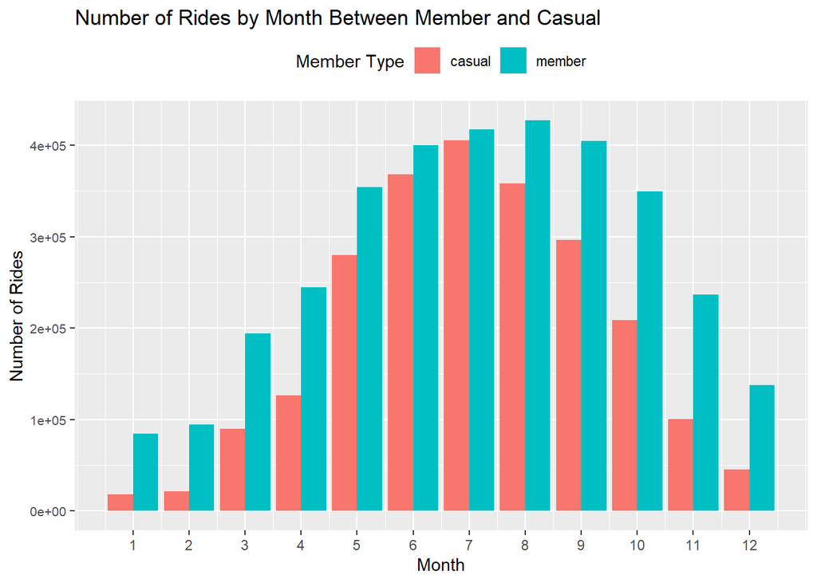

```r
# Plot the number which month has most ride between members & casual.
ggplot(counts_by_month, aes(x = month, y = count, fill = member_casual)) +
  geom_col(position = "dodge") +
  scale_x_continuous(breaks = 1:12) +
  labs(title = "Number of Rides by Month Between Member and Casual",
       x = "Month", y = "Number of Rides",
       fill = "Member Type") +
  theme(legend.position = "top", axis.text.y = element_text(size = 8))
```